# Final project

2023-11-30

```r
library(dplyr)
library(vcd)
```

```r
library(ggplot2)

heart_data <- read.csv("heart_failure_clinical_records_dataset.csv")
head(heart_data, 10)
```

```
##    age anaemia creatinine_phosphokinase diabetes ejection_fraction
## 1   75       0                      582        0                20
## 2   55       0                     7861        0                38
## 3   65       0                      146        0                20
## 4   50       1                      111        0                20
## 5   65       1                      160        1                20
## 6   90       1                       47        0                40
## 7   75       1                      246        0                15
## 8   60       1                      315        1                60
## 9   65       0                      157        0                65
## 10  80       1                      123        0                35
##    high_blood_pressure platelets serum_creatinine serum_sodium sex smoking time
## 1                    1    265000              1.9          130   1       0    4
## 2                    0    263358              1.1          136   1       0    6
## 3                    0    162000              1.3          129   1       1    7
```

[output cut: 18 more lines]

```r
nrow(heart_data)
```

```
## [1] 299
```

Univariate visualisation of categorical variable

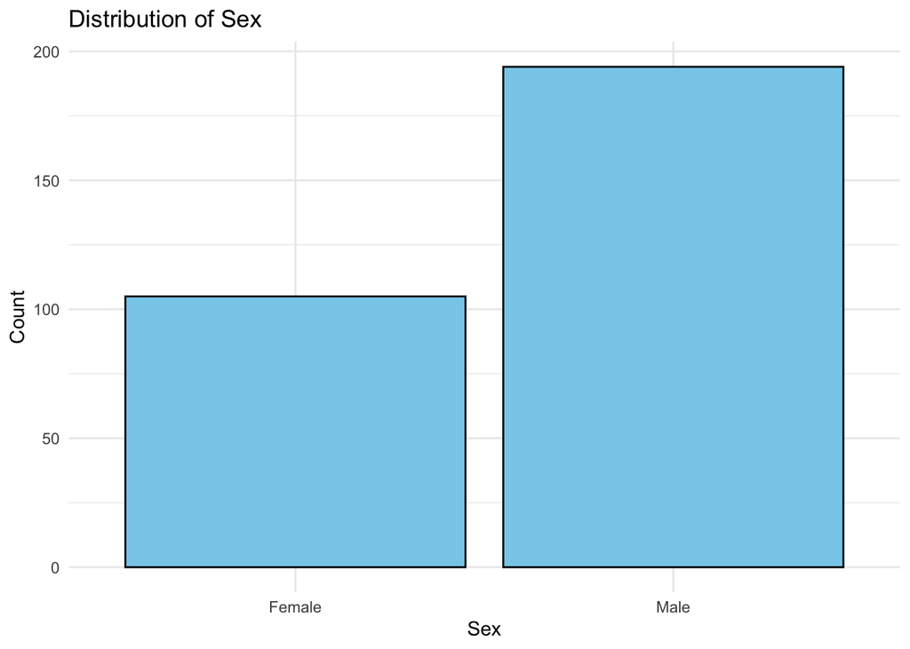

```r
ggplot(heart_data, aes(x = factor(sex))) +
  geom_bar(fill = "skyblue", color = "black") +
  labs(title = "Distribution of Sex",
       x = "Sex",
       y = "Count") +
  scale_x_discrete(labels = c("Female", "Male")) +  # Customize x-axis labels
  theme_minimal()
```

Univariate visualization of a numerical variable

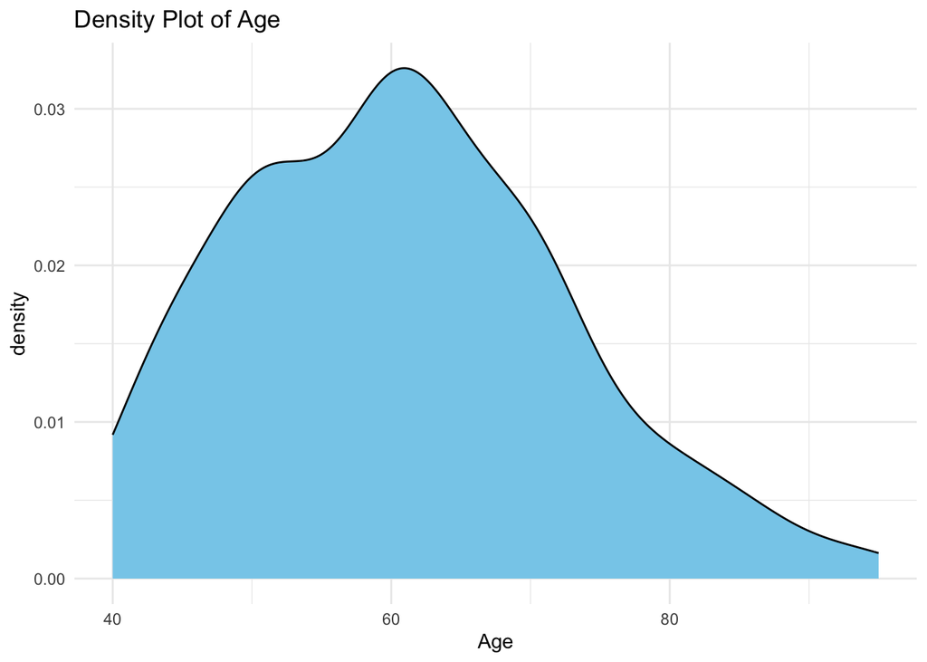

```r
ggplot(heart_data, aes(x = age)) +
  geom_density(fill = "skyblue", color = "black") +
  labs(title = "Density Plot of Age",
       x = "Age") +
  theme_minimal()
```

Research Question 1. Is there a significant association between the presence of specific diseases such anaemia, diabetes, high blood pressure in patients and the occurrence of their death events?

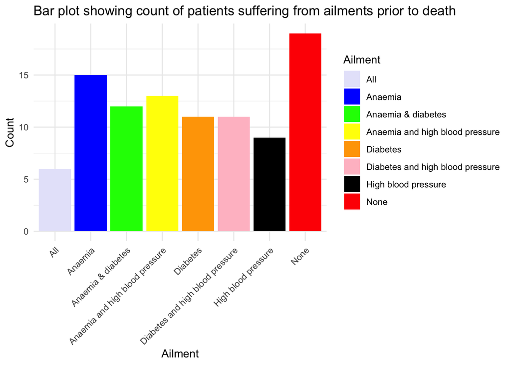

```r
ailments_all <- heart_data %>%
  select(anaemia, diabetes, high_blood_pressure, DEATH_EVENT)

ailments <- ailments_all %>%
  filter(DEATH_EVENT == 1)

anaemia <- ailments %>%
  filter(anaemia == 1, diabetes == 0, high_blood_pressure == 0)
anaemia_count <- nrow(anaemia)

diabetes <- ailments %>%
  filter(anaemia == 0, diabetes == 1, high_blood_pressure == 0)
diabetes_count <- nrow(diabetes)

highbp <- ailments %>%
  filter(anaemia == 0, diabetes == 0, high_blood_pressure == 1)
highbp_count <- nrow(highbp)

anaemia_and_diabetes <- ailments %>%
  filter(anaemia == 1, diabetes == 1, high_blood_pressure == 0)
anaemia_and_diabetes_count <- nrow(anaemia_and_diabetes)

anaemia_and_highbp <- ailments %>%
  filter(anaemia == 1, diabetes == 0, high_blood_pressure == 1)
anaemia_and_highbp_count <- nrow(anaemia_and_highbp)

diabetes_and_highbp <- ailments %>%
  filter(anaemia == 0, diabetes == 1, high_blood_pressure == 1)
diabetes_and_highbp_count <- nrow(diabetes_and_highbp)

all_ailments <- ailments %>%
  filter(anaemia == 1, diabetes == 1, high_blood_pressure == 1)
all_ailments_count <- nrow(all_ailments)

none_ailments <- ailments %>%
  filter(anaemia == 0, diabetes == 0, high_blood_pressure == 0)
none_ailments_count <- nrow(none_ailments)

# Create a data frame
df <- data.frame(
  Ailment = c('Anaemia', 'Diabetes', 'High blood pressure', 'Anaemia & diabetes', 'Anaemia and high blood pressure', 'Diabetes and high blood pressure', 'All', 'None'),
  count = c(anaemia_count, diabetes_count, highbp_count, anaemia_and_diabetes_count, anaemia_and_highbp_count, diabetes_and_highbp_count, all_ailments_count, none_ailments_count)
)

# Create a bar plot
bargraph <- ggplot(df, aes(x = Ailment, y = count, fill = Ailment)) +
  geom_bar(stat = 'identity') +
  scale_fill_manual(values = c('lavender', 'blue', 'green', 'yellow', 'orange', 'pink', 'black', 'red')) +
  labs(title = 'Bar plot showing count of patients suffering from ailments prior to death', x = 'Ailment', y = 'Count') +
  theme_minimal()  + theme(axis.text.x = element_text(angle = 45, hjust = 1))
print(bargraph)
```

Research question 2 What is the impact of anaemia and high blood pressure on the risk of heart failure? Do patients with both anemia and high blood pressure face a greater risk of heart failure compared to individuals with each condition separately, and does this combination result in an additive effect?

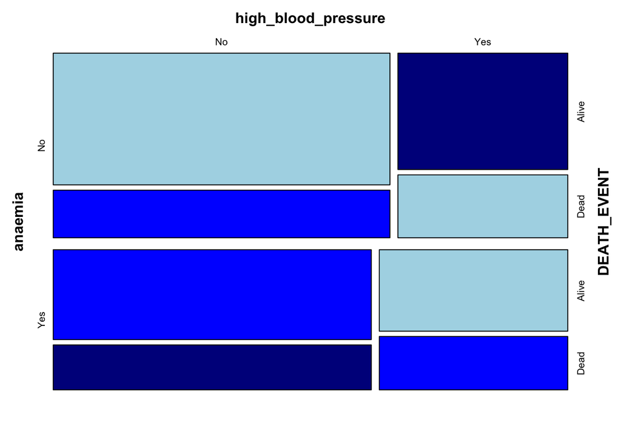

```r
new_heart_data <- select(heart_data, anaemia, high_blood_pressure, DEATH_EVENT)

new_heart_data$anaemia <- factor(new_heart_data$anaemia, levels = c(0, 1), labels = c("No", "Yes"))
new_heart_data$high_blood_pressure <- factor(new_heart_data$high_blood_pressure, levels = c(0, 1), labels = c("No", "Yes"))
new_heart_data$DEATH_EVENT <- factor(new_heart_data$DEATH_EVENT, levels = c("0", "1"), labels = c("Alive", "Dead"))

# Create a mosaic plot
mosaic(~ anaemia + high_blood_pressure + DEATH_EVENT, data = new_heart_data,labeling_args = list(gp_labels = gpar(fontsize = 8)), gp = gpar(fill = c("lightblue", "blue", "darkblue")))
```

```r
logistic_model <- glm(DEATH_EVENT ~ anaemia + high_blood_pressure + anaemia:high_blood_pressure,
                      family = binomial, data = new_heart_data)

# View the summary of the model
summary(logistic_model)
```

```
##
## Call:
## glm(formula = DEATH_EVENT ~ anaemia + high_blood_pressure + anaemia:high_blood_pressure,
##     family = binomial, data = new_heart_data)
##
## Coefficients:
##                                   Estimate Std. Error z value Pr(>|z|)
## (Intercept)                        -1.0176     0.2130  -4.777 1.78e-06 ***
## anaemiaYes                          0.3245     0.3177   1.021    0.307
## high_blood_pressureYes              0.4025     0.3499   1.150    0.250
## anaemiaYes:high_blood_pressureYes  -0.1322     0.5149  -0.257    0.797
## ---
## Signif. codes:  0 '***' 0.001 '**' 0.01 '*' 0.05 '.' 0.1 ' ' 1
##
## (Dispersion parameter for binomial family taken to be 1)
##
##     Null deviance: 375.35  on 298  degrees of freedom
## Residual deviance: 372.22  on 295  degrees of freedom
## AIC: 380.22
##
## Number of Fisher Scoring iterations: 4
```

Coefficients: - Intercept: The estimated log-odds of the death event when `Anaemia` and `High_Blood_Pressure` are both 0. - anaemiaYes: The change in log-odds of the death event associated with the presence of anemia. - high_blood_pressureYes: The change in log-odds of the death event associated with the presence of high blood pressure. - anaemiaYes:high_blood_pressureYes: The change in log-odds of the death event associated with the interaction between anemia and high blood pressure.

Research question 3 Is there any association between ejection fraction and serum creatinine levels, and how do these changes influence the occurrence of death events in heart failure patients?

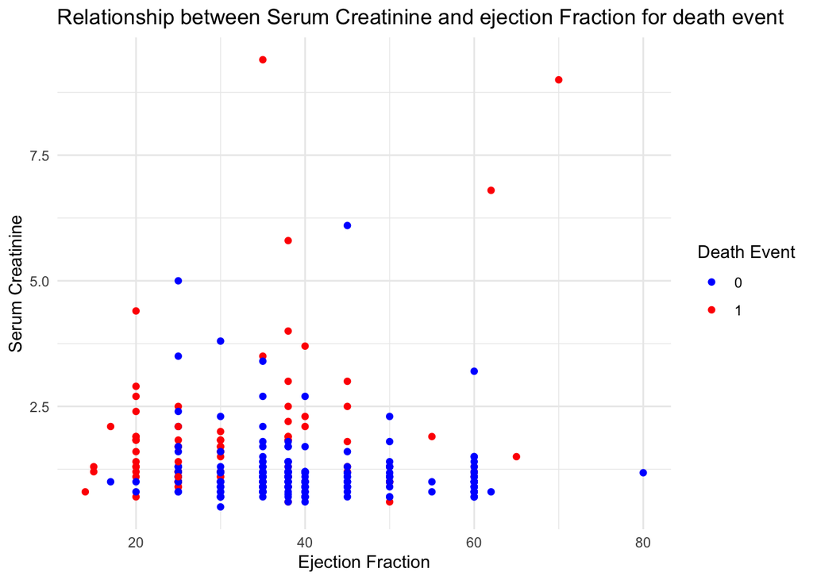

```r
# Visualize the relationship using scatter plots
ggplot(heart_data, aes(x = ejection_fraction, y = serum_creatinine, color = as.factor(DEATH_EVENT))) +
  geom_point() +
  labs(title = "Relationship between Serum Creatinine and ejection Fraction for death event",
       x = "Ejection Fraction",
       y = "Serum Creatinine") +
  scale_color_manual(values = c("blue", "red"), name = "Death Event") +
  theme_minimal()
```